# Developing an AI application

Going forward, AI algorithms will be incorporated into more and more everyday applications. For example, you might want to include an image classifier in a smart phone app. To do this, you'd use a deep learning model trained on hundreds of thousands of images as part of the overall application architecture. A large part of software development in the future will be using these types of models as common parts of applications.

In this project, you'll train an image classifier to recognize different species of flowers. You can imagine using something like this in a phone app that tells you the name of the flower your camera is looking at. In practice you'd train this classifier, then export it for use in your application. We'll be using [this dataset](http://www.robots.ox.ac.uk/~vgg/data/flowers/102/index.html) of 102 flower categories, you can see a few examples below.

[figure not shown]

The project is broken down into multiple steps:

- Load and preprocess the image dataset
- Train the image classifier on your dataset
- Use the trained classifier to predict image content

We'll lead you through each part which you'll implement in Python.

When you've completed this project, you'll have an application that can be trained on any set of labeled images. Here your network will be learning about flowers and end up as a command line application. But, what you do with your new skills depends on your imagination and effort in building a dataset. For example, imagine an app where you take a picture of a car, it tells you what the make and model is, then looks up information about it. Go build your own dataset and make something new.

First up is importing the packages you'll need. It's good practice to keep all the imports at the beginning of your code. As you work through this notebook and find you need to import a package, make sure to add the import up here.

```python
# Imports here
%matplotlib inline
%config InlineBackend.figure_format = 'retina'

import matplotlib.pyplot as plt
import torch
from torch import nn, optim
import torch.nn.functional as F
from torchvision import datasets, transforms, models

import json

from collections import OrderedDict

import time

from workspace_utils import active_session

import PIL
from PIL import Image
import numpy as np

from datetime import datetime
```

## Load the data

Here you'll use `torchvision` to load the data ([documentation](http://pytorch.org/docs/0.3.0/torchvision/index.html)). The data should be included alongside this notebook, otherwise you can [download it here](https://s3.amazonaws.com/content.udacity-data.com/nd089/flower_data.tar.gz). The dataset is split into three parts, training, validation, and testing. For the training, you'll want to apply transformations such as random scaling, cropping, and flipping. This will help the network generalize leading to better performance. You'll also need to make sure the input data is resized to 224x224 pixels as required by the pre-trained networks.

The validation and testing sets are used to measure the model's performance on data it hasn't seen yet. For this you don't want any scaling or rotation transformations, but you'll need to resize then crop the images to the appropriate size.

The pre-trained networks you'll use were trained on the ImageNet dataset where each color channel was normalized separately. For all three sets you'll need to normalize the means and standard deviations of the images to what the network expects. For the means, it's `[0.485, 0.456, 0.406]` and for the standard deviations `[0.229, 0.224, 0.225]`, calculated from the ImageNet images. These values will shift each color channel to be centered at 0 and range from -1 to 1.

```python
data_dir = 'flowers'
train_dir = data_dir + '/train'
valid_dir = data_dir + '/valid'
test_dir = data_dir + '/test'
```

```python
# TODO: Define your transforms for the training, validation, and testing sets

std = [0.229, 0.224, 0.225]
mean = [0.485, 0.456, 0.406]

train_transforms = transforms.Compose([transforms.Resize(224),
                                     transforms.RandomCrop(224),
                                     transforms.RandomRotation(45),
                                     transforms.RandomHorizontalFlip(),
                                     transforms.RandomVerticalFlip(),
                                     transforms.ToTensor(),
                                     transforms.Normalize(mean, std)])

valid_transforms = transforms.Compose([transforms.Resize(224),
                                      transforms.CenterCrop(224),
                                      transforms.ToTensor(),
                                      transforms.Normalize(mean, std)])

test_transforms = transforms.Compose([transforms.Resize(224),
                                      transforms.CenterCrop(224),
                                     transforms.ToTensor(),
                                    transforms.Normalize(mean, std)])


# TODO: Load the datasets with ImageFolder
train_data = datasets.ImageFolder(train_dir, transform=train_transforms)
valid_data = datasets.ImageFolder(valid_dir, transform=valid_transforms)
test_data = datasets.ImageFolder(test_dir, transform=test_transforms)


# TODO: Using the image datasets and the trainforms, define the dataloaders
trainloader = torch.utils.data.DataLoader(train_data, batch_size=64, shuffle=True)
validloader = torch.utils.data.DataLoader(valid_data, batch_size=64, shuffle=True)
testloader = torch.utils.data.DataLoader(test_data, batch_size=64, shuffle=True)
```

### Label mapping

You'll also need to load in a mapping from category label to category name. You can find this in the file `cat_to_name.json`. It's a JSON object which you can read in with the [`json` module](https://docs.python.org/2/library/json.html). This will give you a dictionary mapping the integer encoded categories to the actual names of the flowers.

```python
import json

with open('cat_to_name.json', 'r') as f:
    cat_to_name = json.load(f)

#print(cat_to_name.get("99"))

k = str(99)
print(cat_to_name.get(k))

# actually, we could use this to define the number of output features for the fc network

output_features = len(cat_to_name)
print('output features:', output_features)
```

```
bromelia
output features: 102
```

```python
# show a single image with option to reverse normalization

def show_image (image, label, denormalize=False):

    # use std and mean for ImageNet, same as for normalization in transforms
    std = [0.229, 0.224, 0.225]
    mean = [0.485, 0.456, 0.406]

    if denormalize == True:
        # create a new tensor with same shape as the image
        img = image.new(*image.size())

        # denormalize the stuff
        img[0, :, :] = image[0, :, :] * std[0] + mean[0]
        img[1, :, :] = image[1, :, :] * std[1] + mean[1]
        img[2, :, :] = image[2, :, :] * std[2] + mean[2]

    else:
        img = image

    print('Label {} / {}'.format(label.item(), cat_to_name.get(str(label.item()))))
    plt.imshow(np.transpose(img.numpy(), (1, 2, 0)))
```

```
Label 49 / oxeye daisy
```

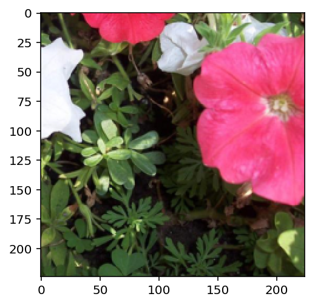

```python
images, labels = next(iter(testloader))
show_image(images[4], labels[4], denormalize=True)
```

# Building and training the classifier

Now that the data is ready, it's time to build and train the classifier. As usual, you should use one of the pretrained models from `torchvision.models` to get the image features. Build and train a new feed-forward classifier using those features.

We're going to leave this part up to you. Refer to [the rubric](https://review.udacity.com/#!/rubrics/1663/view) for guidance on successfully completing this section. Things you'll need to do:

- Load a [pre-trained network](http://pytorch.org/docs/master/torchvision/models.html) (If you need a starting point, the VGG networks work great and are straightforward to use)
- Define a new, untrained feed-forward network as a classifier, using ReLU activations and dropout
- Train the classifier layers using backpropagation using the pre-trained network to get the features
- Track the loss and accuracy on the validation set to determine the best hyperparameters

We've left a cell open for you below, but use as many as you need. Our advice is to break the problem up into smaller parts you can run separately. Check that each part is doing what you expect, then move on to the next. You'll likely find that as you work through each part, you'll need to go back and modify your previous code. This is totally normal!

When training make sure you're updating only the weights of the feed-forward network. You should be able to get the validation accuracy above 70% if you build everything right. Make sure to try different hyperparameters (learning rate, units in the classifier, epochs, etc) to find the best model. Save those hyperparameters to use as default values in the next part of the project.

One last important tip if you're using the workspace to run your code: To avoid having your workspace disconnect during the long-running tasks in this notebook, please read in the earlier page in this lesson called Intro to GPU Workspaces about Keeping Your Session Active. You'll want to include code from the workspace_utils.py module.

**Note for Workspace users:** If your network is over 1 GB when saved as a checkpoint, there might be issues with saving backups in your workspace. Typically this happens with wide dense layers after the convolutional layers. If your saved checkpoint is larger than 1 GB (you can open a terminal and check with `ls -lh`), you should reduce the size of your hidden layers and train again.

```python
# TODO: Build and train your network

# model rationale for choosing vgg16 with batch normalization
# vgg16 should give me the required accuracy with <70%
# I'm not sure about smaller vgg versions, maybe I try them later on
# choosing a deeper version of vgg is not required for this excercise
# and would require too much computing power for very little accuracy gain.
# After researching batch normalization, I decided to use the vgg16_bn model,
# even though bn was not part of the original vgg model. Yet, I expect that
# the model will be faster and more precise when using batch norm

model = models.vgg16_bn(pretrained=True)

# freeze model parameters
for parms in model.parameters():
    parms.requires_grad = False

#model
```

```
Downloading: "https://download.pytorch.org/models/vgg16_bn-6c64b313.pth" to /root/.torch/models/vgg16_bn-6c64b313.pth
```

```python
# replace the classifier
# I choose to follow the existing vgg logic for
# two fc networks with size 4096. According to my
# research it is less memory consuming to use two
# smaller networks instead of one larger network.
# So I'm not choosing something like 25088, 10000
# but rather two 4096 networks. I will see during
# training, if the assumption holds true

# lets make dropout configurable
# vgg default dropout is 0.5! Need to test several
# values
dropout = 0.5

classifier = nn.Sequential(OrderedDict([
                          ('fc1', nn.Linear(25088, 4096)),
                          ('relu1', nn.ReLU()),
                          ('dropout1', nn.Dropout(dropout)),
                          ('fc2', nn.Linear(4096, 4096)),
                          ('relu2', nn.ReLU()),
                          ('dropout2', nn.Dropout(dropout)),
                          ('fc3', nn.Linear(4096, 102)),
                          ('output', nn.LogSoftmax(dim=1))
                          ]))

simpleclassifier = nn.Sequential(OrderedDict([
                          ('fc1', nn.Linear(25088, 4096)),
                          ('relu1', nn.ReLU()),
                          ('dropout1', nn.Dropout(dropout)),
                          ('fc2', nn.Linear(4096, 102)),
                          ('output', nn.LogSoftmax(dim=1))
                          ]))


# replace it in the model
#model.classifier = classifier
model.classifier = simpleclassifier
#model
```

```python
# Time do define the
# << Hyperparameters >>
# https://www.youtube.com/watch?v=aoXOdAUD7IM

learningrate = 0.001
epochs = 2
```

```python
# Check if we have a GPU
device = torch.device('cuda' if torch.cuda.is_available() else 'cpu')
model.to(device)
print('Model running on', device)
```

```
Model running on cuda
```

```python
# lets define the criterion and optimizer
criterion = nn.NLLLoss()
optimizer = optim.Adam(model.classifier.parameters(), lr=learningrate)
```

```python
# introducing learning rate decay
#decay = 0.96
#lr_scheduler = torch.optim.lr_scheduler.ExponentialLR(optimizer=optimizer, gamma=decay)
lr_scheduler = torch.optim.lr_scheduler.StepLR(optimizer, step_size=1, gamma=0.1)
```

## Modularizing it

Below I'm modularizing the training and validation loops

```python
def train(validate_every=0):
    tloss = 0
    starttime = time.time()
    steps = 0
    tacc = 0

    for images, labels in trainloader:
        steps += 1

        # move the data tensors to the correct device
        images, labels = images.to(device), labels.to(device)

        # let the model determine our probabilities
        logps = model.forward(images)

        # calculate loss
        loss = criterion(logps, labels)

        # zero out the gradients
        optimizer.zero_grad()

        # backward step to calculate the gradients
        loss.backward()

        # forward step to optimize the model
        optimizer.step()

        # sum up the loss
        tloss += loss.item()

        # calculate accuracy
        ps = torch.exp(logps)
        top_ps, top_class = ps.topk(1, dim=1)
        equals = (top_class == labels.view(*top_class.shape)).type(torch.FloatTensor)
        tacc += torch.mean(equals).item()

        # fake vars for testing the loop
        #tloss = 3
        #tacc = 4

        if validate_every != 0 and steps % validate_every == 0:
            #print('Validating batch {}/{}'.format(steps, len(trainloader)))
            vtime, vloss, vacc = validate()
            print(f"Validating batch {steps}/{len(trainloader)}.. "
                  f"tloss {tloss/steps:.3f}.. "
                  f"tacc {tacc/steps:.3f}.. "
                  f"vloss {vloss:.3f}.. "
                  f"vacc {vacc:.3f}.. "
                  f"t {vtime:.0f} sec")

    elapsedtime = time.time() - starttime

    return elapsedtime, tloss/len(trainloader), tacc/len(trainloader)
```

```python
def validate():
    vloss = 0
    vacc = 0
    starttime = time.time()

    # disable dropout
    model.eval()

    with torch.no_grad():
        vsteps = 0

        for images, labels in validloader:
            vsteps +=1
            #print('Beginning validloader step {}/{}'.format(vsteps, len(validloader)))

            # make sure it runs on the correct device
            images, labels = images.to(device), labels.to(device)

            # get the logps from model
            logps = model.forward(images)

            # calculate loss and sum up
            batch_loss = criterion(logps, labels)
            vloss += batch_loss.item()

            # calculate accuracy
            ps = torch.exp(logps)
            top_ps, top_class = ps.topk(1, dim=1)
            equals = top_class == labels.view(*top_class.shape)
            vacc += torch.mean(equals.type(torch.FloatTensor)).item()

    model.train()
    elapsedtime = time.time() - starttime

    # fake vars for testing the loop
    #vloss = 8
    #vaccuracy = 80

    return elapsedtime, vloss/len(validloader), vacc/len(validloader)
```

```python
print("{:.10f}".format(lr_scheduler.get_lr()[0]))
lr_scheduler.get_lr()[0]
```

[output not shown]

```
0.01
```

```python
# training loop using modularized train and validate functions

# some vars not affecting the hyperparameters of the model
print_every = 20
t_losses, v_losses, t_accs, v_accs = [], [], [], []

with active_session():
    starttime = time.time()
    print('Classifier training startup at', datetime.now().strftime('%Y-%m-%d %H:%M:%S'))

    for e in range(epochs):
        print('Starting epoch {}/{}'.format(e+1, epochs), 'with learningrate', lr_scheduler.get_lr()[0])
        # train epoch
        ttime, tloss, tacc = train(print_every)
        # validate epoch
        vtime, vloss, vacc = validate()
        # decrease lr
        lr_scheduler.step()

        print(f"Completed epoch {e+1}/{epochs}.. "
            f"tloss {tloss:.3f}.. "
            f"tacc {tacc:.3f}.. "
            f"ttime {ttime:.0f} sec.. "
            f"vloss {vloss:.3f}.. "
            f"vacc {vacc:.3f}.. "
            f"vtime {vtime:.0f} sec.. ")

        # keep data for plotting later
        t_losses.append(tloss)
        v_losses.append(vloss)
        t_accs.append(tacc)
        v_accs.append(vacc)

    elapsedtime = time.time() - starttime
    print(f"Classifier training completed at "
          f"{datetime.now().strftime('%Y-%m-%d %H:%M:%S')} "
          f"in {elapsedtime:.0f} sec")
```

[output not shown]

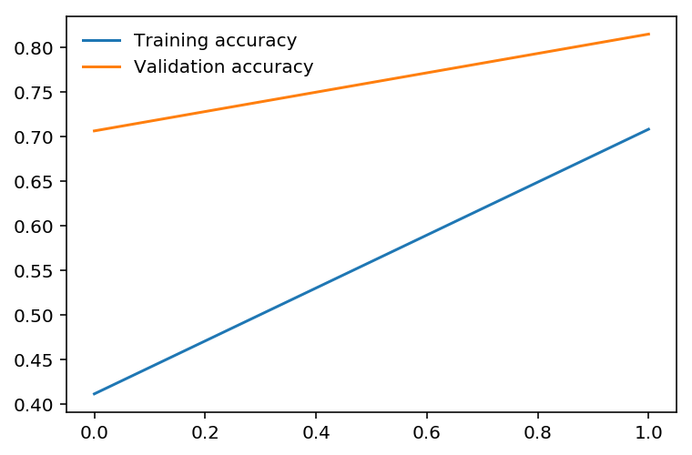

```python
plt.plot(t_accs, label='Training accuracy')
plt.plot(v_accs, label='Validation accuracy')
plt.legend(frameon=False)
plt.show()
```

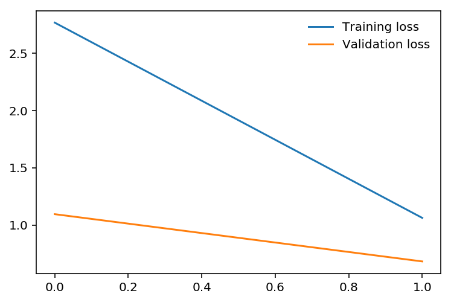

```python
# print losses and accuracy over epochs
plt.plot(t_losses, label='Training loss')
plt.plot(v_losses, label='Validation loss')
plt.legend(frameon=False)
plt.show()
```

## changelog

- dropout 0.1 -> 0.5, brought down the loss but not significantly
- lr 0.01 -> 0.001, looks like loss goes down, but not really
- fc2 4096 -> 1024, loss goes further down, but accuracy is still way below anything good
- after 10 epochs, accuracy finally reaches 2% (0.0235) :-/
- looks like I forgot to use += for calculating the accuracy, just had =, so it never could go up :)

## Testing your network

It's good practice to test your trained network on test data, images the network has never seen either in training or validation. This will give you a good estimate for the model's performance on completely new images. Run the test images through the network and measure the accuracy, the same way you did validation. You should be able to reach around 70% accuracy on the test set if the model has been trained well.

```python
# TODO: Do validation on the test set
acc = 0
with torch.no_grad():
    model.eval()
    for images, labels in testloader:
        images, labels = images.to(device), labels.to(device)
        ps = torch.exp(model.forward(images))
        top_ps, top_class = ps.topk(1, dim=1)
        equals = top_class == labels.view(*top_class.shape)
        acc += torch.mean(equals.type(torch.FloatTensor)).item()
    model.train()
    #print('Accuracy:', acc/len(testloader))
    accuracy = acc/len(testloader)
    print(f"Accuracy: {accuracy*100:.2f}%")
    print("Nice job!" if accuracy>0.7 else "Model not sufficient!")
```

```
Accuracy: 80.67%
Nice job!
```

## Save the checkpoint

Now that your network is trained, save the model so you can load it later for making predictions. You probably want to save other things such as the mapping of classes to indices which you get from one of the image datasets: `image_datasets['train'].class_to_idx`. You can attach this to the model as an attribute which makes inference easier later on.

`model.class_to_idx = image_datasets['train'].class_to_idx`

Remember that you'll want to completely rebuild the model later so you can use it for inference. Make sure to include any information you need in the checkpoint. If you want to load the model and keep training, you'll want to save the number of epochs as well as the optimizer state, `optimizer.state_dict`. You'll likely want to use this trained model in the next part of the project, so best to save it now.

```python
# TODO: Save the checkpoint

model.class_to_idx = train_data.class_to_idx

checkpoint = {'arch': 'vgg16_bn',
              'classifier': model.classifier,
              'optimizer': optimizer,
              'lr_scheduler': lr_scheduler,
              'state_dict': model.state_dict(),
              'epochs': epochs,
              'learningrate': learningrate,
              'class_to_idx': train_data.class_to_idx
             }

torch.save(checkpoint, checkpoint['arch']+'_'+'checkpoint.pth')
```

```python
print(optimizer.state_dict())
print(checkpoint['optimizer'])
my_optim = checkpoint['optimizer']

print(my_optim.state_dict())
```

[output not shown]

[output cut: 96 more lines]

[output not shown]

```python
print(checkpoint['classifier'])
model.classifier = nn.Sequential()
print(model.classifier)
model.classifier = checkpoint['classifier']
print(model.classifier)
```

```
Sequential(
  (fc1): Linear(in_features=25088, out_features=4096, bias=True)
  (relu1): ReLU()
  (dropout1): Dropout(p=0.5)
  (fc2): Linear(in_features=4096, out_features=102, bias=True)
  (output): LogSoftmax()
)
Sequential()
Sequential(
  (fc1): Linear(in_features=25088, out_features=4096, bias=True)
  (relu1): ReLU()
  (dropout1): Dropout(p=0.5)
  (fc2): Linear(in_features=4096, out_features=102, bias=True)
  (output): LogSoftmax()
)
```

## Loading the checkpoint

At this point it's good to write a function that can load a checkpoint and rebuild the model. That way you can come back to this project and keep working on it without having to retrain the network.

```python
# TODO: Write a function that loads a checkpoint and rebuilds the model
def load_checkpoint(file):
    # Check if we have a GPU
    device = torch.device('cuda' if torch.cuda.is_available() else 'cpu')
    print('Loading into', device)
    if torch.cuda.is_available():
        checkpoint = torch.load(file, map_location=lambda storage, loc: storage.cuda(0))
    else:
        checkpoint = torch.load(file, map_location=lambda storage, loc: storage)

    #model = models.checkpoint['arch']
    model = getattr(models, checkpoint['arch'])(pretrained=True)

    for param in model.parameters():
        param.requires_grad = False

    model.classifier = checkpoint['classifier']
    model.load_state_dict(checkpoint['state_dict'], strict=False)
    model.class_to_idx = checkpoint['class_to_idx']
    optimizer = checkpoint['optimizer']
    lr_scheduler = checkpoint['lr_scheduler']
    epochs = checkpoint['epochs']

    return model
```

```python
model = load_checkpoint('vgg16_bn_checkpoint.pth')
print('Model loading completed...')
print(model.classifier)
```

[output not shown]

# Inference for classification

Now you'll write a function to use a trained network for inference. That is, you'll pass an image into the network and predict the class of the flower in the image. Write a function called `predict` that takes an image and a model, then returns the top $K$ most likely classes along with the probabilities. It should look like

```
probs, classes = predict(image_path, model)
print(probs)
print(classes)
> [ 0.01558163  0.01541934  0.01452626  0.01443549  0.01407339]
> ['70', '3', '45', '62', '55']
```

First you'll need to handle processing the input image such that it can be used in your network.

## Image Preprocessing

You'll want to use `PIL` to load the image ([documentation](https://pillow.readthedocs.io/en/latest/reference/Image.html)). It's best to write a function that preprocesses the image so it can be used as input for the model. This function should process the images in the same manner used for training.

First, resize the images where the shortest side is 256 pixels, keeping the aspect ratio. This can be done with the [`thumbnail`](http://pillow.readthedocs.io/en/3.1.x/reference/Image.html#PIL.Image.Image.thumbnail) or [`resize`](http://pillow.readthedocs.io/en/3.1.x/reference/Image.html#PIL.Image.Image.thumbnail) methods. Then you'll need to crop out the center 224x224 portion of the image.

Color channels of images are typically encoded as integers 0-255, but the model expected floats 0-1. You'll need to convert the values. It's easiest with a Numpy array, which you can get from a PIL image like so `np_image = np.array(pil_image)`.

As before, the network expects the images to be normalized in a specific way. For the means, it's `[0.485, 0.456, 0.406]` and for the standard deviations `[0.229, 0.224, 0.225]`. You'll want to subtract the means from each color channel, then divide by the standard deviation.

And finally, PyTorch expects the color channel to be the first dimension but it's the third dimension in the PIL image and Numpy array. You can reorder dimensions using [`ndarray.transpose`](https://docs.scipy.org/doc/numpy-1.13.0/reference/generated/numpy.ndarray.transpose.html). The color channel needs to be first and retain the order of the other two dimensions.

```python
# Test image
filepath = "./flowers/test/13/image_05745.jpg"
```

```python
from PIL import Image
from matplotlib.pyplot import imshow
import numpy as np

def process_image(image):
    ''' Scales, crops, and normalizes a PIL image for a PyTorch model,
        returns an Numpy array
    '''
    img = Image.open(image)
    #imshow(img)
    # using thumbnail because it respects ratio
    img.thumbnail((255,255))

    # center crop
    crop_size = 224
    left  = int(img.size[0]/2-crop_size/2)
    upper = int(img.size[1]/2-crop_size/2)
    right = left+crop_size
    lower = upper+crop_size

    cropped_img = img.crop((left,upper,right,lower))
    #print(cropped_img.size)

    #imshow(np.asarray(cropped_img))
    #imshow(np.asarray(img))

    # use std and mean for ImageNet, same as for normalization in transforms
    std = [0.229, 0.224, 0.225]
    mean = [0.485, 0.456, 0.406]

    transform = transforms.Compose([transforms.ToTensor(),
                                    transforms.Normalize(mean, std)])

    norm_img = transform(cropped_img)

    #print(type(norm_img))
    return norm_img
```

```python
process_image(filepath)
```

[output not shown]

```
tensor([[[-2.1179, -2.1179, -2.1179,  ..., -2.1179, -2.1179, -2.1179],
         [-2.1179, -2.1179, -2.1179,  ..., -2.1179, -2.1179, -2.1179],
         [-2.1179, -2.1179, -2.1179,  ..., -2.1179, -2.1179, -2.1179],
         ...,
         [-2.1179, -2.1179, -2.1179,  ..., -2.1179, -2.1179, -2.1179],
         [-2.1179, -2.1179, -2.1179,  ..., -2.1179, -2.1179, -2.1179],
         [-2.1179, -2.1179, -2.1179,  ..., -2.1179, -2.1179, -2.1179]],

        [[-2.0357, -2.0357, -2.0357,  ..., -2.0357, -2.0357, -2.0357],
         [-2.0357, -2.0357, -2.0357,  ..., -2.0357, -2.0357, -2.0357],
         [-2.0357, -2.0357, -2.0357,  ..., -2.0357, -2.0357, -2.0357],
         ...,
         [-2.0357, -2.0357, -2.0357,  ..., -2.0357, -2.0357, -2.0357],
         [-2.0357, -2.0357, -2.0357,  ..., -2.0357, -2.0357, -2.0357],
         [-2.0357, -2.0357, -2.0357,  ..., -2.0357, -2.0357, -2.0357]],

        [[-1.8044, -1.8044, -1.8044,  ..., -1.8044, -1.8044, -1.8044],
         [-1.8044, -1.8044, -1.8044,  ..., -1.8044, -1.8044, -1.8044],
         [-1.8044, -1.8044, -1.8044,  ..., -1.8044, -1.8044, -1.8044],
         ...,
         [-1.8044, -1.8044, -1.8044,  ..., -1.8044, -1.8044, -1.8044],
         [-1.8044, -1.8044, -1.8044,  ..., -1.8044, -1.8044, -1.8044],
         [-1.8044, -1.8044, -1.8044,  ..., -1.8044, -1.8044, -1.8044]]])
```

To check your work, the function below converts a PyTorch tensor and displays it in the notebook. If your `process_image` function works, running the output through this function should return the original image (except for the cropped out portions).

```python
def imshow(image, ax=None, title=None):
    """Imshow for Tensor."""
    if ax is None:
        fig, ax = plt.subplots()

    # PyTorch tensors assume the color channel is the first dimension
    # but matplotlib assumes is the third dimension
    image = image.numpy().transpose((1, 2, 0))

    # Undo preprocessing
    mean = np.array([0.485, 0.456, 0.406])
    std = np.array([0.229, 0.224, 0.225])
    image = std * image + mean

    # Image needs to be clipped between 0 and 1 or it looks like noise when displayed
    image = np.clip(image, 0, 1)

    ax.imshow(image)

    return ax
```

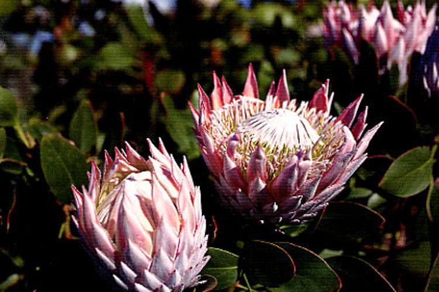

```python
# The original Image
# Test image
#filepath = "./flowers/test/13/image_05745.jpg"
filepath = "./flowers/test/13/image_05761.jpg"
img = Image.open(filepath)
img
```

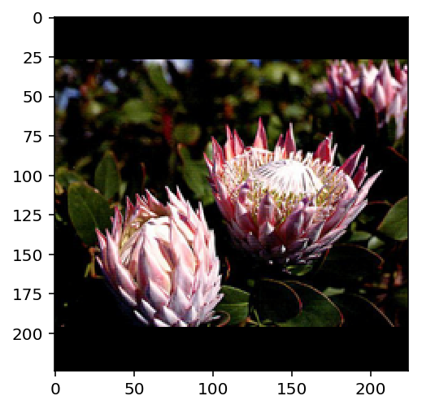

```python
# And now lets test imshow
imshow(process_image(filepath))
```

## Class Prediction

Once you can get images in the correct format, it's time to write a function for making predictions with your model. A common practice is to predict the top 5 or so (usually called top-$K$) most probable classes. You'll want to calculate the class probabilities then find the $K$ largest values.

To get the top $K$ largest values in a tensor use [`x.topk(k)`](http://pytorch.org/docs/master/torch.html#torch.topk). This method returns both the highest `k` probabilities and the indices of those probabilities corresponding to the classes. You need to convert from these indices to the actual class labels using `class_to_idx` which hopefully you added to the model or from an `ImageFolder` you used to load the data (see here). Make sure to invert the dictionary so you get a mapping from index to class as well.

Again, this method should take a path to an image and a model checkpoint, then return the probabilities and classes.

```
probs, classes = predict(image_path, model)
print(probs)
print(classes)
> [ 0.01558163  0.01541934  0.01452626  0.01443549  0.01407339]
> ['70', '3', '45', '62', '55']
```

```python
def predict(image_path, model, topk=5):
    ''' Predict the class (or classes) of an image using a trained deep learning model.
    '''

    # TODO: Implement the code to predict the class from an image file

    # Check if we have a GPU
    device = torch.device('cuda' if torch.cuda.is_available() else 'cpu')

    # Pre-process the image
    image = process_image(image_path)

    # Add a dimension for the batch
    image = torch.unsqueeze(image,0)

    # Move image and model to the correct device
    image.to(device)
    model.to(device)

    with torch.no_grad():
        model.eval()
        ps = torch.exp(model.forward(image))
        top_ps, top_class = ps.topk(topk, dim=1)
        model.train()

    return(top_ps, top_class)
```

```python
# Load our model
print('Loading model')
model = load_checkpoint('vgg16_bn_checkpoint.pth')
print('Loading model completed')
```

```
Loading model
Loading into cpu
```

```
Downloading: "https://download.pytorch.org/models/vgg16_bn-6c64b313.pth" to /root/.torch/models/vgg16_bn-6c64b313.pth
```

```
Loading model completed
```

```
Predicting class
Prob: 90.01% .. Class: 1 .. Name: pink primrose
Prob: 2.50% .. Class: 76 .. Name: morning glory
Prob: 1.83% .. Class: 86 .. Name: tree mallow
Prob: 1.55% .. Class: 77 .. Name: passion flower
Prob: 0.87% .. Class: 51 .. Name: petunia
[0.9000997543334961, 0.025038527324795723, 0.018326301127672195, 0.015484572388231754, 0.008705604821443558]
['pink primrose', 'morning glory', 'tree mallow', 'passion flower', 'petunia']
```

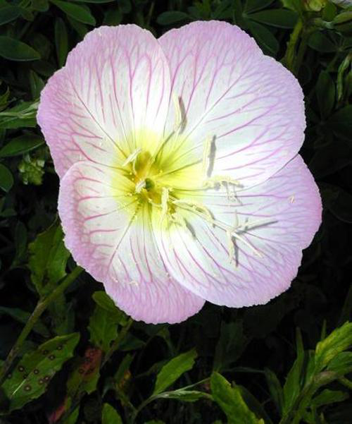

```python
# Test image
#filepath = "./flowers/test/13/image_05745.jpg"
#filepath = "./flowers/test/10/image_07090.jpg"
filepath = "./flowers/test/1/image_06743.jpg"

with open('cat_to_name.json', 'r') as f:
    cat_to_name = json.load(f)

print('Predicting class')
probs, labels = predict(filepath, model, 5)

#Reverse the index so we can lookup by key (and not by value)
index = dict(map(reversed, model.class_to_idx.items()))

p_list = probs.squeeze().tolist()
l_list = labels.squeeze().tolist()

i = 0
class_list = []
for l in l_list:
    classification = list(model.class_to_idx)[l]
    name = cat_to_name.get(str(classification))
    prob = p_list[i]
    print('Prob: {:.2f}% .. Class: {} .. Name: {}  '.format(prob*100, classification, name))
    class_list.append(name)
    i+=1

print(p_list)
print(class_list)


# No longer needed ... this was my attempt before I figured out to reverse the dict :-/
#i = 0
#for label in l_list:
#    position = list(model.class_to_idx.values()).index(label)
#    classification = list(model.class_to_idx)[position]
#    name = cat_to_name.get(str(classification))
#    prob = p_list[i]
#    #print('Label', label, 'Position', position, 'Class', classification, 'Name', name, 'Prob ', prob)
#    print('Prob: {:.2f}% .. Class: {} .. Name: {}  '.format(prob*100, classification, name))
#    i+=1

#print(p_list)
#print(c_list)
#print(model.class_to_idx)
image = Image.open(filepath)
image
```

## Sanity Checking

Now that you can use a trained model for predictions, check to make sure it makes sense. Even if the testing accuracy is high, it's always good to check that there aren't obvious bugs. Use `matplotlib` to plot the probabilities for the top 5 classes as a bar graph, along with the input image. It should look like this:

[figure not shown]

You can convert from the class integer encoding to actual flower names with the `cat_to_name.json` file (should have been loaded earlier in the notebook). To show a PyTorch tensor as an image, use the `imshow` function defined above.

```
Predicting class
```

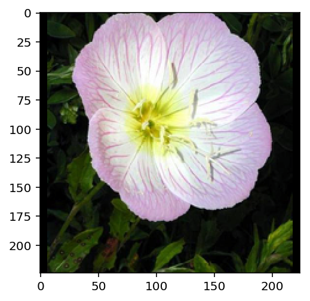

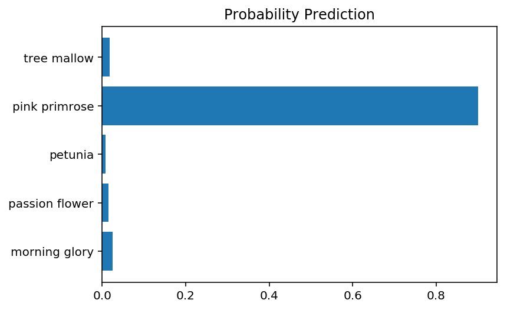

```python
# TODO: Display an image along with the top 5 classes

#filepath = "./flowers/test/13/image_05745.jpg"
#filepath = "./flowers/test/10/image_07090.jpg"
filepath = "./flowers/test/1/image_06743.jpg"

# Show the image in the same way as above by using the imshow function
imshow(process_image(filepath))

with open('cat_to_name.json', 'r') as f:
    cat_to_name = json.load(f)

print('Predicting class')
probs, labels = predict(filepath, model, 5)

#Reverse the index so we can lookup by key (and not by value)
index = dict(map(reversed, model.class_to_idx.items()))

p_list = probs.squeeze().tolist()
l_list = labels.squeeze().tolist()

i = 0
class_list = []
for l in l_list:
    classification = list(model.class_to_idx)[l]
    name = cat_to_name.get(str(classification))
    prob = p_list[i]
    class_list.append(name)
    i+=1

plt.figure()
plt.barh(class_list, p_list)
plt.title('Probability Prediction')
plt.show()
```

# Archive

Below is stuff I created earlier but replaced with better code

```python
# finally ... lets define the training loop!!

# some vars not affecting the hyperparameters of the model
steps = 0
running_loss = 0
print_every = 20

running_losses = []
validation_losses = []
accuracies = []

with active_session():
    for e in range(epochs):
        #print('Starting epoch {}/{}'.format(e+1, epochs))
        starttime = time.time()

        for images, labels in trainloader:
            steps += 1
            #if steps % print_every == 0:
            #    print('Beginning trainloader step {}/{}'.format(steps, len(trainloader)))

            # move the data tensors to the correct device
            images, labels = images.to(device), labels.to(device)

            # let the model determine our probabilities
            logps = model.forward(images)

            # calculate loss
            loss = criterion(logps, labels)

            # zero out the gradients
            optimizer.zero_grad()

            # backward step to calculate the gradients
            loss.backward()

            # forward step to optimize the model
            optimizer.step()

            # sum up the loss
            running_loss += loss.item()

            # VALIDATION
            # every some steps, validate our model to see how
            # validation loss behaves. We want it to go down
            # so lets monitor it while training
            if steps % print_every == 0:
                valid_loss = 0
                accuracy = 0

                # disable dropout
                model.eval()
                with torch.no_grad():
                    vsteps = 0

                    for images, labels in validloader:

                        vsteps +=1
                        #print('Beginning validloader step {}/{}'.format(vsteps, len(validloader)))

                        # make sure it runs on the correct device
                        images, labels = images.to(device), labels.to(device)
                        # get the logps from model
                        logps = model.forward(images)
                        # calculate loss and sum up
                        batch_loss = criterion(logps, labels)
                        valid_loss += batch_loss.item()

                        # calculate accuracy
                        ps = torch.exp(logps)
                        top_ps, top_class = ps.topk(1, dim=1)
                        equals = top_class == labels.view(*top_class.shape)
                        #print('top_class', top_class, 'labels', labels.view(*top_class.shape))
                        accuracy += torch.mean(equals.type(torch.FloatTensor)).item()

                    # print out the values
                    print(f"Epoch {e+1}/{epochs}.. "
                          f"Train loss: {running_loss/print_every:.3f}.. "
                          f"Validation loss: {valid_loss/len(validloader):.3f}.. "
                          f"Validation accuracy: {accuracy/len(validloader):.4f}")

                    # keep the losses over time, so we can
                    # print out a graph later, then reset it
                    running_losses.append(running_loss/print_every)
                    validation_losses.append(valid_loss/len(validloader))
                    accuracies.append(accuracy/len(validloader))
                    running_loss = 0

                    # reset the model to train mode so dropout is enabled
                    model.train()
                    steps = 0
        # lr decay
        lr_scheduler.step()

        print(f"Completed epoch {e+1}/{epochs} "
              f"in {time.time()-starttime:.0f} sec ")
        #print('last top_class\n', top_class)
        #print('last labels\n', labels.view(*top_class.shape))
        #print('last equals\n', equals)
```

[output not shown]

[output not shown]